# Data Sciece Capstone - Milestone Report

Sangwon Han

Jan 11, 2019

# Overview

The goal of this project is to:

1. Demonstrate that you’ve downloaded the data and have successfully loaded it in.
2. Create a basic report of summary statistics about the data sets.
3. Report any interesting findings that you amassed so far.
4. Get feedback on your plans for creating a prediction algorithm and Shiny app.

# Download and load data

```r
# Download
download.file("https://d396qusza40orc.cloudfront.net/dsscapstone/dataset/Coursera-SwiftKey.zip", destfile ="Coursera-SwiftKey.zip")
```

```r
# Unzip
unzip("./Coursera-SwiftKey.zip")
```

Check local setting and change it.

```r
Sys.getlocale()
```

```
## [1] "LC_COLLATE=Korean_Korea.949;LC_CTYPE=Korean_Korea.949;LC_MONETARY=Korean_Korea.949;LC_NUMERIC=C;LC_TIME=Korean_Korea.949"
```

```r
Sys.setlocale('LC_ALL','C')
```

```
## [1] "C"
```

```r
# Load data for english languge into R
blogs <- readLines(con <- file("./final/en_US/en_US.blogs.txt"), encoding = "UTF-8", skipNul = TRUE)
news <- readLines(con <- file("./final/en_US/en_US.news.txt"), encoding = "UTF-8", skipNul = TRUE)
```

```
## Warning in readLines(con <- file("./final/en_US/en_US.news.txt"), encoding
## = "UTF-8", : incomplete final line found on './final/en_US/en_US.news.txt'
```

```r
twitter <- readLines(con <- file("./final/en_US/en_US.twitter.txt"), encoding = "UTF-8", skipNul = TRUE)
```

However, with warning message news dataset was not loaded properly. Let’s compare the size of loaded file and original file

```r
# Size of original file
news.size <- file.info("./final/en_US/en_US.news.txt")$size / (1024^2)
news.size
```

```
## [1] 196.2775
```

```r
# Size of loaded file
news.size1 <- sum(nchar(news, "bytes")) / (1024^2)
news.size1
```

```
## [1] 14.9572
```

The news dataset is reloaded by opening connection in binary mode. Check the size of loaded file again.

```r
# reload file
news2 <- readLines(con <- file("./final/en_US/en_US.news.txt", open = "rb"), encoding = "UTF-8", skipNul = TRUE)
news.size2 <- sum(nchar(news2, "bytes")) / (1024^2)
news.size2
```

```
## [1] 194.3506
```

# Summary statistics

```r
# Size in megabytes
blogs.size <- file.info("./final/en_US/en_US.blogs.txt")$size / (1024^2)
twitter.size <- file.info("./final/en_US/en_US.twitter.txt")$size / (1024^2)
```

```r
# Line counts
blogs.line <- length(blogs)
news.line <- length(news2)
twitter.line <- length(twitter)
```

```r
# Word counts
suppressMessages(library(stringi))
blogs.words <- sum(stri_count_words(blogs))
news.words <- sum(stri_count_words(news2))
twitter.words <- sum(stri_count_words(twitter))
```

```r
# Summary data
data.frame(type = c("blogs", "news", "twitter"), megabytes = c(blogs.size, news.size, twitter.size), lines = c(blogs.line, news.line, twitter.line), words = c(blogs.words, news.words, twitter.words))
```

```
##      type megabytes   lines    words
## 1   blogs  200.4242  899288 37546239
## 2    news  196.2775 1010242 34762395
## 3 twitter  159.3641 2360148 30093413
```

```r
cup <- c(blogs, news)
str(cup)
```

```
##  chr [1:976547] "In the years thereafter, most of the Oil fields and platforms were named after pagan “gods”." ...
```

# Cleaning data

I will randomly sample 1% of data from blog dataset for the exploratory analysis

```r
# Sample data
suppressMessages(library(tm))
suppressMessages(library(stringr))
set.seed(12345)
blogs.sample <- sample(blogs, blogs.line * 0.01)

# Create volatile corpus
corpus <- VCorpus(VectorSource(blogs.sample), readerControl = list(reader = readPlain, language = "en"))

# Clean data (Remove invalid character)
toSpace <- content_transformer(function(x, pattern) gsub(pattern, " ", x))
corpus <- tm_map(corpus, toSpace, "(f|ht)tp(s?)://(.*)[.][a-z]+") # remove URL
corpus <- tm_map(corpus, toSpace, "@[^\\s]+")
corpus <- tm_map(corpus, stripWhitespace) # Multiple space to single space
corpus <- tm_map(corpus, tolower) # Uppercase to lowercase
corpus <- tm_map(corpus, removeNumbers) # Remove number
corpus <- tm_map(corpus, removeWords, stopwords("en"))
corpus <- tm_map(corpus, removePunctuation) # Remove punctuation such as .,;:
corpus <- tm_map(corpus, PlainTextDocument)
```

# Exploratory analysis

Find the top 10 mostly used words in the dataset. First of all, formulate functions to extract word counts for unigram, bigram, and trigram and to make a plot.

```r
suppressMessages(library(RWeka))
```

```r
options(mc.cores = 1) # Do not use multicore

getCounts <- function(tdm){
        count <- sort(rowSums(as.matrix(tdm)), decreasing = TRUE)
        return(data.frame(word = names(count), count = count))
}

bigram <- function(x) NGramTokenizer(x, Weka_control(min = 2, max = 2))
trigram <- function(x) NGramTokenizer(x, Weka_control(min = 3, max = 3))


suppressMessages(library(ggplot2))
makePlot <- function(x, label, barcolor){
        ggplot(x[1:10,], aes(reorder(word, -count), count)) +
                geom_bar(stat = "identity", fill = barcolor) +
                xlab(label) + theme(axis.text.x = element_text(angle = 45, hjust = 1, size = 10)) +
                ylab("Word counts")
}
```

check memory limits and expand it

```r
memory.limit()
```

```
## [1] 8048
```

```r
memory.limit(size = 8048*5)
```

```
## [1] 40240
```

```r
count_uni <- getCounts(removeSparseTerms(TermDocumentMatrix(corpus), 0.9999))
count_bi <- getCounts(removeSparseTerms(TermDocumentMatrix(corpus, control = list(tokenize = bigram)), 0.9999))
count_tri <- getCounts(removeSparseTerms(TermDocumentMatrix(corpus, control = list(tokenize = trigram)), 0.9999))
```

Here, I plot a histogram showing top 10 unigrams, bigrams and trigrams for blog dataset.

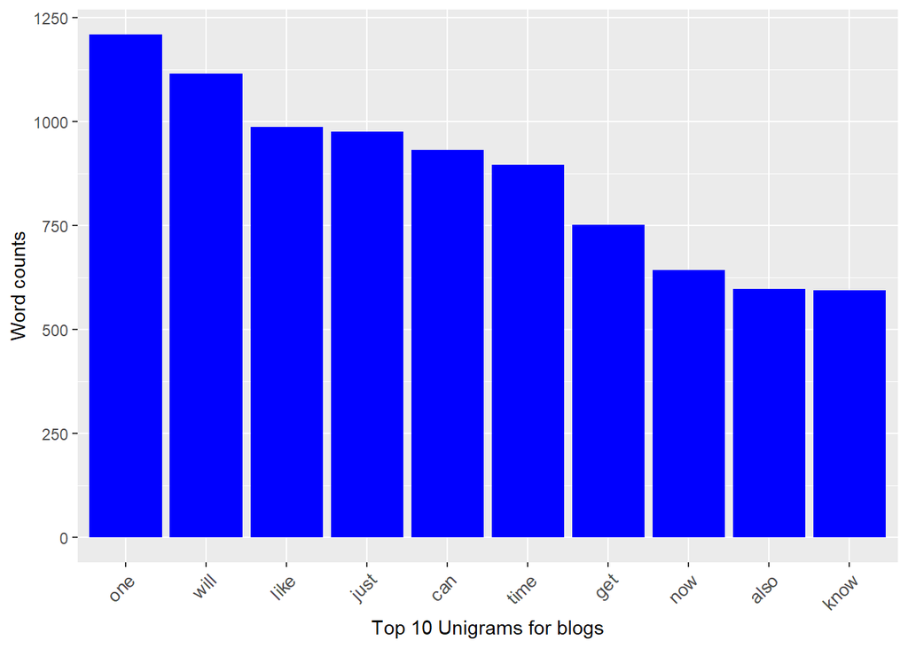

```r
makePlot(count_uni, "Top 10 Unigrams for blogs", barcolor = "blue")
```

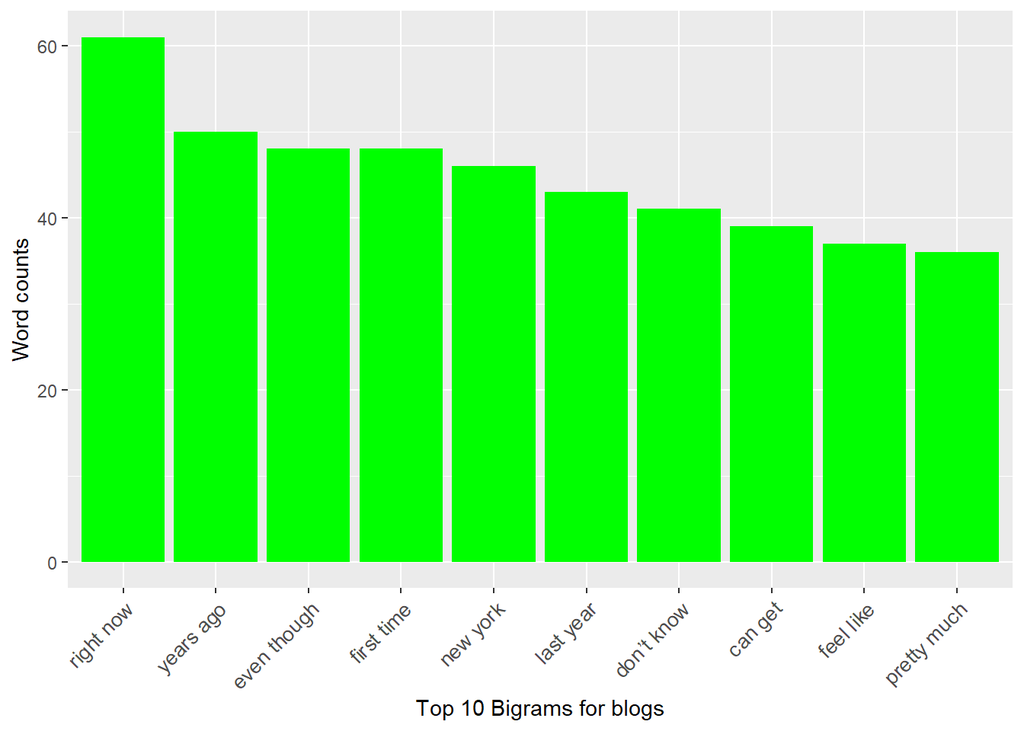

```r
makePlot(count_bi, "Top 10 Bigrams for blogs", barcolor = "green")
```

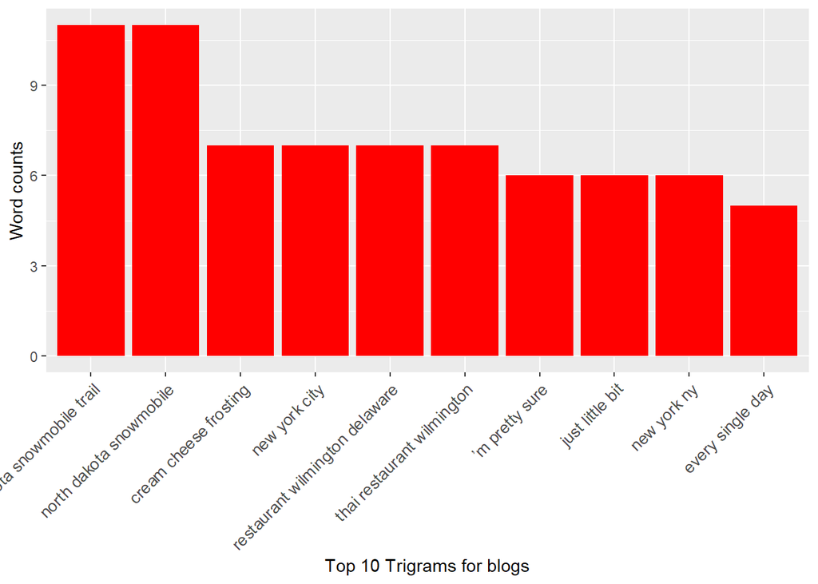

```r
makePlot(count_tri, "Top 10 Trigrams for blogs", barcolor = "red")
```

# Next steps on your plans for creating a prediction algorithm and Shiny app

The next steps of this project is to make a predictive algorithm and presents interactive programs in a Shiny app. The possible predictive algorithm is to predict the following words according to the trigram. Bigram and unigram models will be engaged when trigram model fails to predict the following word.

The Shiny app will present a interactive user App having a text input box. If user enter a phrase, this App will return the next word which is most likely to be appeared.